# ST558 Project 2

Mu-Tien, Lee

- Require package
- Read in data
- Summarize the training data
- Training Model
  - Tree-based model
  - Boosted tree model
- Predicting using the best tree-base model
- Predicting using the best boosted-tree model

# Require package

```r
#install.packages("")
library(knitr)
library(rmarkdown)
library(MuMIn)
library(tidyverse)
library(caret)
library(corrplot)
library(readxl)
library(caret)
library(ggiraphExtra)
library(knitr)
library(ggplot2)
library(ggpubr)
library(rpart.plot)
library(rpart)
library(DT)
```

# Read in data

```r
#read in hour data
HourData <- read.csv("hour.csv")
HourData<- HourData %>% select(-casual, -registered)
HourData$yr <- as.factor(HourData$yr)
HourData$holiday <- as.factor(HourData$holiday)
HourData$workingday <- as.factor(HourData$workingday)

#filter data by weekday
HourData <-HourData %>% filter(weekday==params$w)
#showing data
HourData <-HourData %>% select(-weekday, -workingday,-instant)
tbl_df(HourData)
```

```
## # A tibble: 2,453 x 12
##    dteday     season yr     mnth    hr holiday weathersit  temp atemp   hum windspeed   cnt
##    <fct>       <int> <fct> <int> <int> <fct>        <int> <dbl> <dbl> <dbl>     <dbl> <int>
##  1 2011-01-04      1 0         1     0 0                1  0.16 0.182  0.55    0.104      5
##  2 2011-01-04      1 0         1     1 0                1  0.16 0.182  0.59    0.104      2
##  3 2011-01-04      1 0         1     2 0                1  0.14 0.152  0.63    0.134      1
##  4 2011-01-04      1 0         1     4 0                1  0.14 0.182  0.63    0.0896     2
##  5 2011-01-04      1 0         1     5 0                1  0.12 0.152  0.68    0.104      4
##  6 2011-01-04      1 0         1     6 0                1  0.12 0.152  0.74    0.104     36
##  7 2011-01-04      1 0         1     7 0                1  0.12 0.152  0.74    0.134     94
##  8 2011-01-04      1 0         1     8 0                1  0.14 0.152  0.69    0.164    179
##  9 2011-01-04      1 0         1     9 0                1  0.16 0.152  0.64    0.224    100
## 10 2011-01-04      1 0         1    10 0                2  0.16 0.136  0.69    0.328     42
## # … with 2,443 more rows
```

```r
#Separate dataset into train (70%) and test (30%) data set
set.seed(1997)
train <- sample(1:nrow(HourData), size = nrow(HourData)*0.7)
test <- dplyr::setdiff(1:nrow(HourData), train)
HourDataTrain <- HourData[train, ]
HourDataTest <- HourData[test, ]
```

# Summarize the training data

Here I will show you some summary of my training dataset.  
1. I conduct a histogram of the rental count, since this is my response variable.  
2. I built up a summary table of all the weather measurement.  
3. I also showing the weather summary via a boxplot.  
4. I plot the rental count distributed by time.  
5. I plot the rental count distributed by weather situation.

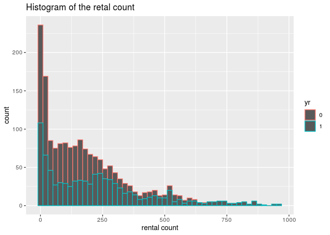

```r
# plot the histogram of rental count
hist <- ggplot(data=HourDataTrain, aes(x=cnt))+geom_histogram(binwidth = 20, aes(color=yr))
hist <-hist+labs(title="Histogram of the retal count", x="rental count")
hist <-hist+scale_fill_discrete(labels=c(2011,2012))
hist
```

```r
#prin out summary table for tempature humidity and windspeed
sum <- HourDataTrain%>% select(c(temp, atemp, hum, windspeed))
kable(apply(sum, 2,summary), caption="Numeric Summary for weather measurement")
```

|  | temp | atemp | hum | windspeed |
| --- | --- | --- | --- | --- |
| Min. | 0.1000000 | 0.0909000 | 0.1600000 | 0.0000000 |
| 1st Qu. | 0.3600000 | 0.3485000 | 0.4900000 | 0.1045000 |
| Median | 0.5200000 | 0.5000000 | 0.6600000 | 0.1940000 |
| Mean | 0.5076179 | 0.4861924 | 0.6405649 | 0.1928702 |
| 3rd Qu. | 0.6600000 | 0.6212000 | 0.8100000 | 0.2836000 |
| Max. | 0.9400000 | 0.8485000 | 1.0000000 | 0.7761000 |

Numeric Summary for weather measurement

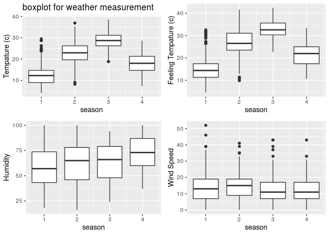

```r
#plot the boxplot of tempature humidity and windspeed (not genralized amount)
#plot base
boxplot <- ggplot(data = HourDataTrain, aes(x=season))
#adding 4 variables
tem <-boxplot+geom_boxplot(aes(y=temp*41, group=season))+labs(y="Tempature (c)", title = "boxplot for weather measurement")
fetem <-boxplot+geom_boxplot(aes(y=atemp*50, group=season))+labs(y="Feeling Tempature (c)")
hum <-boxplot+geom_boxplot(aes(y=hum*100, group=season))+labs(y="Humidity")
wind <-boxplot+geom_boxplot(aes(y=windspeed*67, group=season))+labs(y="Wind Speed")
#combine 4 plots into 1
ggarrange(tem, fetem, hum , wind, ncol = 2, nrow = 2)
```

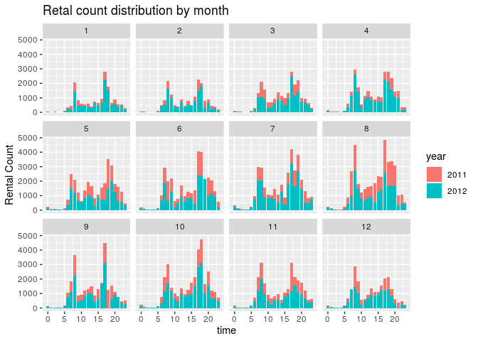

```r
# plot the count distribution among time and weather
# by time
barplot1<-ggplot(data = HourDataTrain, aes(x=hr))+geom_col(aes(y=cnt, fill=yr))+facet_wrap(~mnth)
barplot1 <- barplot1+labs(x="time", y="Rental Count", title="Retal count distribution by month" )
barplot1+scale_fill_discrete(name="year", labels=c(2011,2012))
```

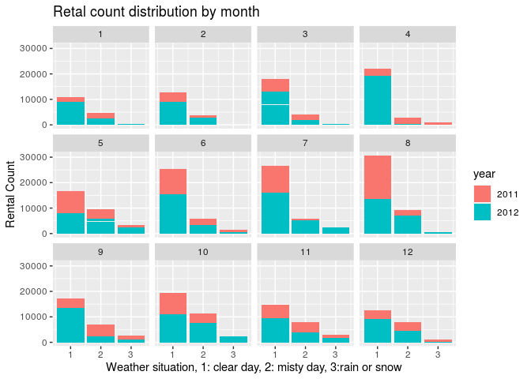

```r
# by weather
barplot2 <-ggplot(data = HourDataTrain, aes(x=weathersit))+geom_col(aes(y=cnt, fill=yr))+facet_wrap(~mnth)
barplot2 <- barplot2+labs(x="Weather situation, 1: clear day, 2: misty day, 3:rain or snow", y="Rental Count", title="Retal count distribution by month" )
barplot2+scale_fill_discrete(name="year", labels=c(2011,2012))
```

# Training Model

Here I use two different method to train my model. First method is using a tree-based models with leave one out cross validation. For the second method, I use the boosted tree model with cross validation. Both two training are done using the `train` function from `caret` package. The data was cantered and scaled before training.

## Tree-based model

Since our respons variable is continuous. I use the regression tree model to training my data. The `method= "rpart"` was used in `train` function  
Moreover, because I want to use the leave-one-out cross validation for this training, therefore,the `method= "LOOCV"` was used in `trainControl`.  
We can adjust the grid parameter by ourselves. Since the default result shows that `cp` should be very small to have a lowest RMSE. I set a range [0.0001,0.0005] to fit for every weekday.  
Something to notice, because the `cp` is too small, when I draw my regression tree, it seems like a mess.

```r
# set up training control, using leave one out cross validation.
set.seed(615)
trctrl <- trainControl(method = "LOOCV", number = 1)

# getModelInfo("rpart")
# training using regression tree models with cp in [0.0001,0.0005]
# since the cp seems have to be really small when I used the default cp to train

model1 <- cnt~season+yr+mnth+hr+holiday+weathersit+temp+atemp+hum+windspeed

RegTree_fit1 <- train(model1, data = HourDataTrain, method = "rpart",
                 trControl=trctrl,
                 preProcess = c("center", "scale"),
                 tuneGrid=expand.grid(cp=seq(0.0001,0.0005,0.00004))
)

# show the training result
RegTree_fit1
```

```
## CART
##
## 1717 samples
##   10 predictors
##
## Pre-processing: centered (10), scaled (10)
## Resampling: Leave-One-Out Cross-Validation
## Summary of sample sizes: 1716, 1716, 1716, 1716, 1716, 1716, ...
## Resampling results across tuning parameters:
##
##   cp       RMSE      Rsquared   MAE
##   0.00010  64.74131  0.8810503  37.57114
##   0.00014  64.74553  0.8810451  37.52645
##   0.00018  64.78678  0.8808487  37.58862
##   0.00022  64.72886  0.8810907  37.55060
##   0.00026  64.72868  0.8810750  37.36727
##   0.00030  65.06455  0.8798016  38.51957
##   0.00034  65.07244  0.8797776  38.56849
##   0.00038  65.48247  0.8782669  39.24470
##   0.00042  65.71466  0.8774079  39.52932
##   0.00046  66.03233  0.8762008  40.11507
##   0.00050  66.00767  0.8762390  40.08113
##
## RMSE was used to select the optimal model using the smallest value.
## The final value used for the model was cp = 0.00026.
```

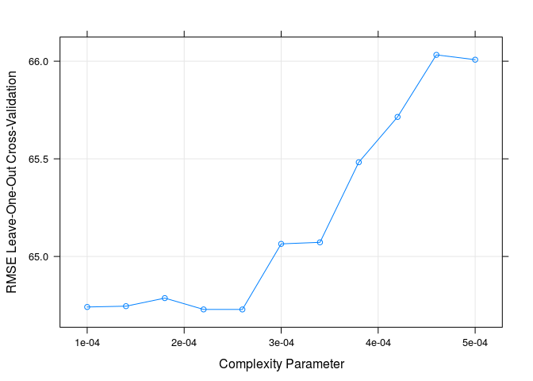

```r
# plot the RMSE of selected cp
plot(RegTree_fit1)
```

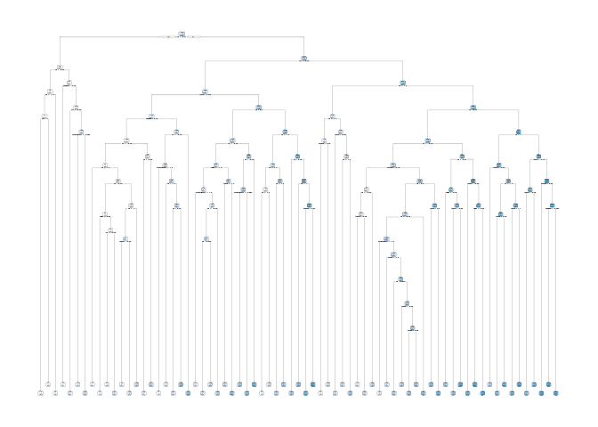

```r
# plot my final tree model
rpart.plot(RegTree_fit1$finalModel)
```

## Boosted tree model

Here I want to training my data using boosted tree model. The `method= "gbm"` was used in `train` function  
Because I want to use thecross validation for this training, therefore,the `method= "cv"` was used in `trainControl`.  
We can adjust the grid parameter by ourselves. I set a range of number of tree [100,1250] and interaction 5~11 to fit for every weekday.

```r
# set up training control, using cross validation with 10 folder
set.seed(615)
trctrl <- trainControl(method = "cv", number = 10)

# training using boosted tree models with boosting interation in [700,1250] and try max tree depth 5~9
model2 <- cnt~season+yr+mnth+hr+holiday+weathersit+temp+atemp+hum+windspeed
RegTree_fit2 <- train(model2, data = HourDataTrain, method = "gbm",
                trControl=trctrl,
                preProcess = c("center", "scale"),
                tuneGrid=expand.grid(n.trees=seq(100,1250,25),
                                     interaction.depth=5:11,
                                     shrinkage=0.1, n.minobsinnode=10)
                 )
```

```r
# show the training result of boosted tree
RegTree_fit2$bestTune
```

```
##     n.trees interaction.depth shrinkage n.minobsinnode
## 291     300                11       0.1             10
```

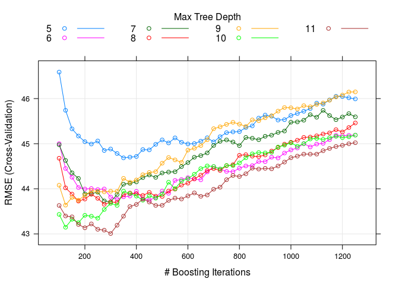

```r
# plot the RMSE of different parameters
plot(RegTree_fit2)
```

# Predicting using the best tree-base model

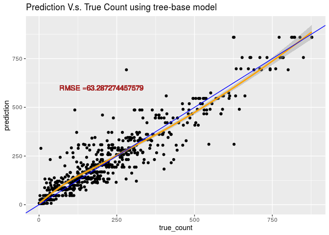

```r
# predict use predict function
tree_pred <- predict(RegTree_fit1, newdata = HourDataTest)

#Calculate the Root MSE
RMSE_tree<- sqrt(mean((tree_pred-HourDataTest$cnt)^2))
label <- paste0("RMSE =", RMSE_tree)

# plot the prediction
count <- data.frame(true_count=HourDataTest$cnt,prediction=tree_pred )
predPlot <- ggplot(data=count, aes(x=true_count,y=prediction))
predPlot <- predPlot+labs(title="Prediction V.s. True Count using tree-base model")+geom_point()
predPlot <- predPlot+geom_smooth(color="orange")+geom_abline(aes(intercept=0,slope=1), color="blue")
predPlot <- predPlot+geom_text(x=200, y=600,label=label, color="brown")
predPlot
```

# Predicting using the best boosted-tree model

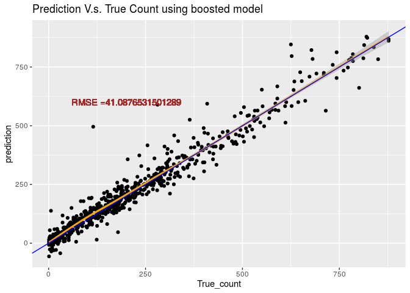

```r
# predict use predict function
boosted_pred <- predict(RegTree_fit2, newdata = HourDataTest)

#Calculate the Root MSE
RMSE_boosted <- sqrt(mean((boosted_pred-HourDataTest$cnt)^2))
lab <- paste0("RMSE =", RMSE_boosted)
# plot the prediction
count2 <- data.frame(True_count=HourDataTest$cnt,prediction=boosted_pred )
pred_plot <- ggplot(data=count2, aes(x=True_count,y=prediction))
pred_plot <- pred_plot+labs(title="Prediction V.s. True Count using boosted model")+geom_point()
pred_plot <- pred_plot+geom_smooth(color="orange")+geom_abline(aes(intercept=0,slope=1), color="blue")
pred_plot <- pred_plot+geom_text(x=200, y=600,label=lab, color=" brown")
pred_plot
```

```r
# create a linear model using repeated cross-validation
linear_mod <- train(cnt~season+yr+mnth+hr+holiday+weathersit+temp+atemp+hum+windspeed,
                    data=HourDataTrain,
                    method='lm',
                    preProcess=c("center", "scale"),
                    metric='RMSE',
                    tuneLength=10,
                    trControl=trainControl(method='repeatedcv', number=10, repeats=3)
                    )

# display the results of the linear model
summary(linear_mod)
```

```
##
## Call:
## lm(formula = .outcome ~ ., data = dat)
##
## Residuals:
##     Min      1Q  Median      3Q     Max
## -340.76  -95.32  -37.89   47.51  614.28
##
## Coefficients:
##             Estimate Std. Error t value Pr(>|t|)
## (Intercept)  189.768      3.640  52.139  < 2e-16 ***
## season        18.301      9.300   1.968   0.0492 *
## yr1           42.602      3.680  11.578  < 2e-16 ***
## mnth           7.519      9.291   0.809   0.4185
## hr            60.898      3.828  15.909  < 2e-16 ***
## holiday1     -10.653      4.450  -2.394   0.0168 *
## weathersit    -7.395      4.254  -1.738   0.0824 .
## temp         -33.530     31.286  -1.072   0.2840
## atemp         76.435     31.279   2.444   0.0146 *
## hum          -33.906      4.643  -7.302 4.33e-13 ***
## windspeed      8.173      3.972   2.058   0.0398 *
## ---
## Signif. codes:  0 '***' 0.001 '**' 0.01 '*' 0.05 '.' 0.1 ' ' 1
##
## Residual standard error: 150.8 on 1706 degrees of freedom
## Multiple R-squared:  0.3541, Adjusted R-squared:  0.3503
## F-statistic: 93.52 on 10 and 1706 DF,  p-value: < 2.2e-16
```

```r
# compare our linear model to our test data
linear_pred <- predict(linear_mod, newdata=HourDataTest)
postResample(linear_pred, HourDataTest$cnt)
```

```
##        RMSE    Rsquared         MAE
## 155.1096182   0.3296524 115.1139742
```